# 政治学方法論Ⅰ－課題6

Yuko Sato

2016年5月31日

課題：「再現可能な研究」になるよう心がけながら、以下の問題に答え、結果を R マークダウンファイル（.Rmd）と HTML ファイルで提出しなさい。

## 1. ソートアルゴリズム

与えられた数値ベクトルの要素を、小さい順（デフォルト）に並べ替える関数を作りなさい。また、引数の設定によって大きい順にも並べ替えられるようにしなさい。

ここで、ソートアルゴリズムの中でも最も基本的なバブルソートを用いて、数値ベクトルの並べ替えを行う関数を定義することとする。

```r
bubble_sort <- function(vec, d) {
  #引数：
  #vec: 与えるベクトル
  #d：並べ替えの定義（0以上であれば小さい順、0未満であれば大きい順）

  count <- 0
  while(1){
    count_swaps <- 0

  # d が0以上の場合（小さい順に並べ替える）
  if (d > 0){
    for (i in 1 : (length(vec) - 1 - count)) {
      if (vec[i] > vec[i+1]) {
        s <- vec[i]
        vec[i] <- vec[i+1]
        vec[i+1] <- s
        count_swaps <- count_swaps + 1
      }
    }

  # d が0未満の場合（大きい順に並べ替える）
  }else{

    for (i in 1 : (length(vec) - 1 - count)) {
      if (vec[i] < vec[i + 1]) {
        s <- vec[i]
        vec[i] <- vec[i+1]
        vec[i+1] <- s
        count_swaps <- count_swaps + 1
      }
    }
  }
    count <- count + 1
    if(count_swaps == 0) break
  }
vec　#ベクトルで返す
}

#関数を使ってテストする。
bubble_sort(c(5,3,1,10,2), 0)
```

```
## [1] 10  5  3  2  1
```

```r
bubble_sort(1:10, 1)
```

```
##  [1]  1  2  3  4  5  6  7  8  9 10
```

## 2. 階乗

階乗を計算する関数を作りなさい。ただし、$n$（非負の整数）の階乗は$n!$と表し、

$$n!= n(n-1)(n-2)...1,\\
0!=1$$

である。

```r
my_factorial <- function(n) {
    # 階乗を計算する関数
    # arg: n = 非負の整数
    # return: nの階乗
    output <- 1 # n=0の場合を定義
    if (n > 0) { # n > 0 の場合のみ実行
        for (i in 1:n) {
            output <- output * i
        }
    }
    return(output)
}

#実際に値を与えて計算する。
my_factorial(5)
```

```
## [1] 120
```

```r
my_factorial(3)
```

```
## [1] 6
```

```r
my_factorial(0)
```

```
## [1] 1
```

## 3. 組み合わせ

自分で作った階乗の関数を利用して、組み合わせを計算する関数を作りなさい。

ただし、$n$個から$k$個選ぶ組み合わせは、

$$\begin{pmatrix} n \\ k \end{pmatrix}= \frac{n!}{k!(n-k)!}$$

である。

```r
my_choose <- function(n, k){
  #n:非負の整数
  #k:nの中から選ぶ個数（n未満の非負の整数）

  if ((n >0) && (k >0)){ # n > 0 かつ k > 0 の場合のみ実行
    output <- (my_factorial(n)) / (my_factorial(k) * my_factorial(n-k))

  }else{
    output <- 0　#n=0かつKが0以外の場合を定義
    if(k == 0){ #k = 0の場合を定義
      output <- 1}
    }
  return(output)
}

#実際に値を与えて計算する。
my_choose(5,3)
```

```
## [1] 10
```

```r
my_choose(0,3)
```

```
## [1] 0
```

```r
my_choose(3,0)
```

```
## [1] 1
```

## 4. 二項分布の確率質量

自分で作った組み合わせの関数を利用して、二項分布の確率質量を求める関数を作りなさい。ただし、二項分布の確率質量関数$f(x)$は、
$$f(x)= \begin{pmatrix} n \\ x \end{pmatrix}p^x(1-p)^{n-x} (x= 0,1,2,...,n)$$
である。ここで、$n$はベルヌーイ試行の回数、$p$は1回のベルヌーイ試行における成功確率である。

```r
my_dbinom <- function(n,x,p){
  #引数：
  #n：ベルヌーイ試行回数（非負の整数）
  #x：事象が起こる回数(x= 0,1,2...,n)
  #p：ベルヌ―イ試行における成功確率 (0 =< p =< 1)

  if ((n >0) && (x >0)){　#nとkが共に0以上の場合
      output <- my_choose(n,x) * (p^x)*(1-p)^(n-x)

    }else{
      output <- 0 #それ以外の場合を定義
      if(x == 0){　#x=0の場合
        output <- (1-p)^n
      }
    }
  return(output)
}

#実際に値を与えて計算する。
my_dbinom(10,3,0.3)
```

```
## [1] 0.2668279
```

```r
my_dbinom(3,0,0.5)
```

```
## [1] 0.125
```

```r
my_dbinom(0,3,0.2)
```

```
## [1] 0
```

```r
my_dbinom(0,0,0.7)
```

```
## [1] 1
```

## 5.確率質量の図示

自分で作った二項分布の関数を使い、$n$が2,3,5,10の場合について、確率質量を図示しなさい。$p$の値については任意とする。ただし、二つ以上の$p$で図を作りなさい。その際、for()ループを少なくとも一回使いなさい。

$x$はそれぞれの$n$に対して0から$n$までの整数をとる可能性がある。 このため、ここでシミュレーションを行う関数を定義し、$x$が0から$n$までの値をとった場合に得られる確率をデータフレームとして保存する。

```r
sim_prob <- function(n,p){
  #引数：
  #n：ベルヌーイ試行回数（非負の整数）
  #p：ベルヌ―イ試行における成功確率 (0 =< p =< 1)

  #結果を保存するためのデータフレームを作成
  col_names <- c('x','prob')
  df <- as.data.frame(matrix(rep(NA,(n+1) *length(col_names)),
                             ncol = length(col_names)))
  names(df)<- col_names

  df[n+1,] <- c(0, (1-p)^n) #x=0の場合を調整

   for(i in 1:n) { #xが1からnまでの値をとる場合の確率質量を計算
     x<- i
     prob <- my_dbinom(n,x,p)

   #結果を保存
   df[i,]<- c(x, prob)
   }
return(df)
}
```

それぞれの値について関数を用いてシミュレーションを行い、得たデータをデータフレームとして保存する。

```r
sim_1 <- sim_prob(2, 0.5) #n=2, p=0.5の場合
sim_2 <- sim_prob(2, 0.3) #n=2, p=0.3の場合
sim_3 <- sim_prob(3, 0.5) #n=3, p=0.5の場合
sim_4 <- sim_prob(3, 0.3) #n=3, p=0.3の場合
sim_5 <- sim_prob(5, 0.5) #n=5, p=0.5の場合
sim_6 <- sim_prob(5, 0.3) #n=5, p=0.3の場合
sim_7 <- sim_prob(10, 0.5) #n=10, p=0.5の場合
sim_8 <- sim_prob(10, 0.3) #n=10, p=0.3の場合
```

以上によって得られたデータをもとに、確率質量を図示する。

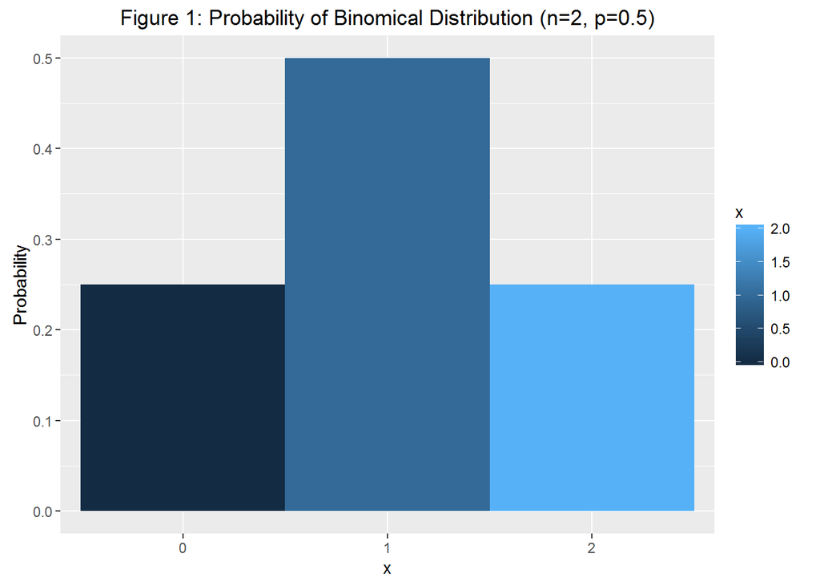

```r
library(ggplot2)
g <- ggplot(sim_1, aes (x = as.factor(x), y = prob, fill = x ))+
     geom_bar(width = 1, stat = "identity")+
     labs(x="x", y=("Probability"),
     title = ("Figure 1: Probability of Binomical Distribution (n=2, p=0.5)"))
plot(g)
```

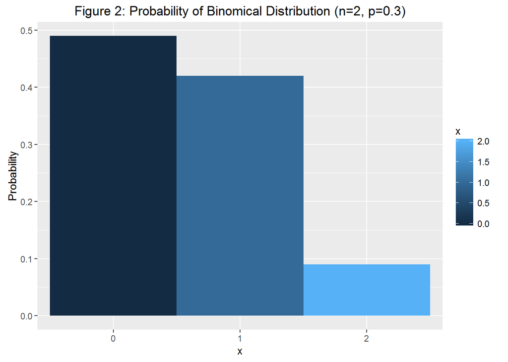

```r
g <- ggplot(sim_2, aes (x = as.factor(x), y = prob, fill = x ))+
     geom_bar(width = 1, stat = "identity")+
     labs(x="x", y=("Probability"),
     title = ("Figure 2: Probability of Binomical Distribution (n=2, p=0.3)"))
plot(g)
```

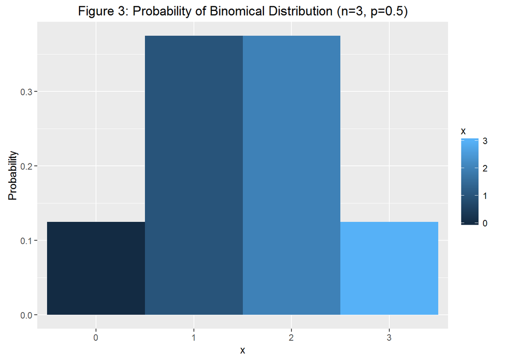

```r
g <- ggplot(sim_3, aes (x = as.factor(x), y = prob, fill = x ))+
     geom_bar(width = 1, stat = "identity")+
     labs(x="x", y=("Probability"),
     title = ("Figure 3: Probability of Binomical Distribution (n=3, p=0.5)"))
plot(g)
```

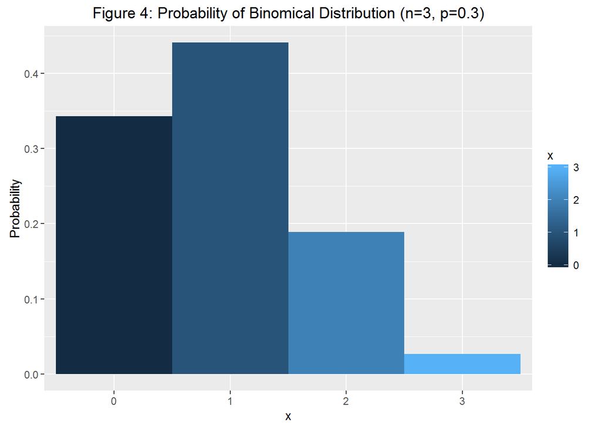

```r
g <- ggplot(sim_4, aes (x = as.factor(x), y = prob, fill = x ))+
     geom_bar(width = 1, stat = "identity")+
     labs(x="x", y=("Probability"),
     title = ("Figure 4: Probability of Binomical Distribution (n=3, p=0.3)"))
plot(g)
```

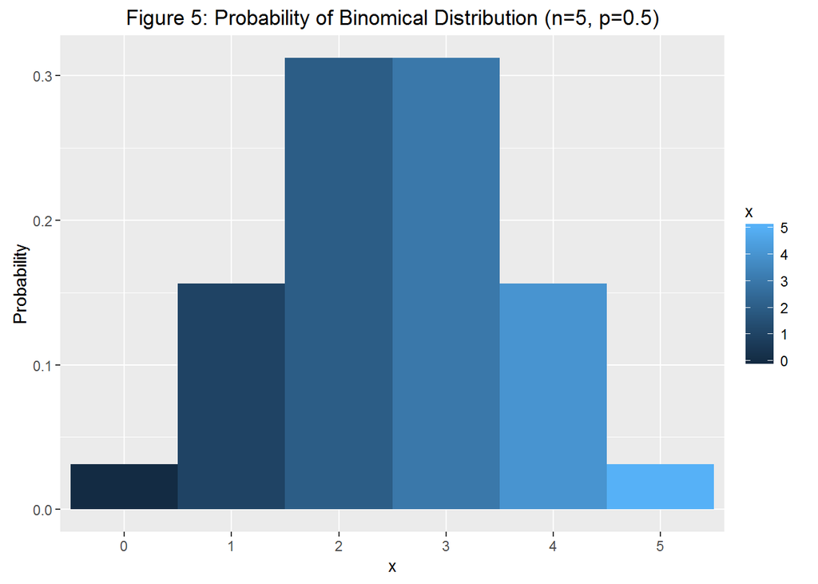

```r
g <- ggplot(sim_5, aes (x = as.factor(x), y = prob, fill = x ))+
     geom_bar(width = 1, stat = "identity")+
     labs(x="x", y=("Probability"),
     title = ("Figure 5: Probability of Binomical Distribution (n=5, p=0.5)"))
plot(g)
```

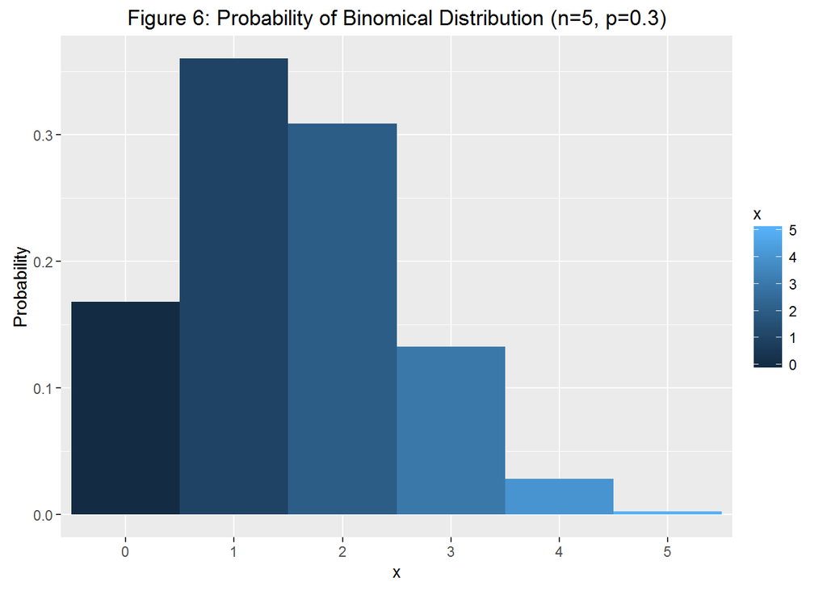

```r
g <- ggplot(sim_6, aes (x = as.factor(x), y = prob, fill = x ))+
     geom_bar(width = 1, stat = "identity")+
     labs(x="x", y=("Probability"),
     title = ("Figure 6: Probability of Binomical Distribution (n=5, p=0.3)"))
plot(g)
```

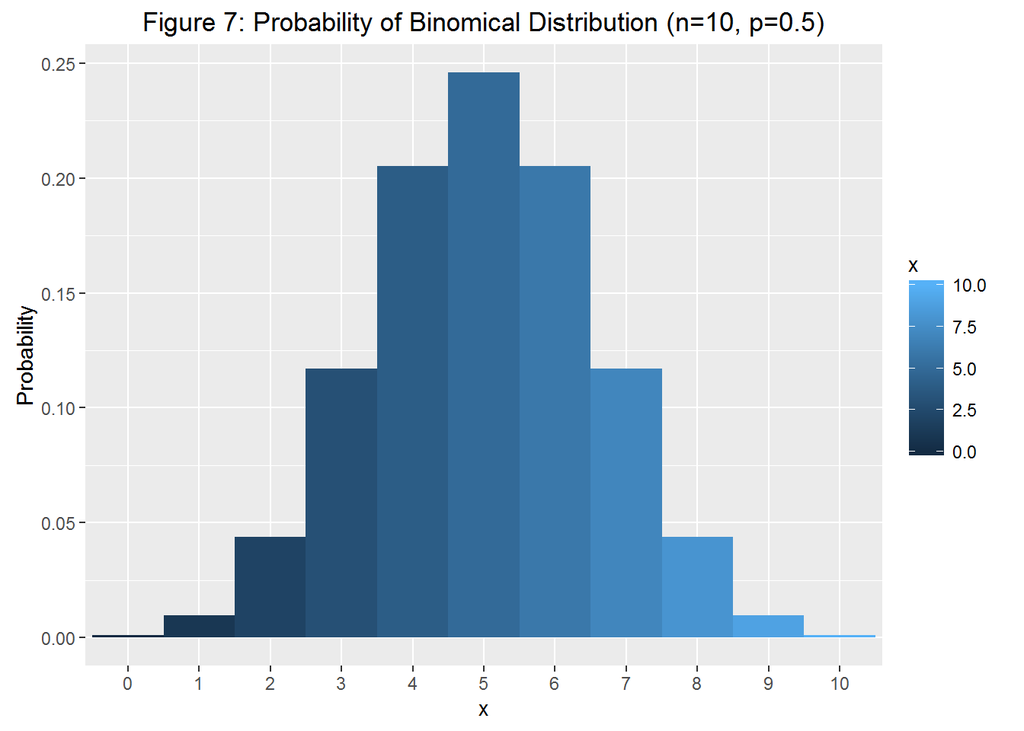

```r
g <- ggplot(sim_7, aes (x = as.factor(x), y = prob, fill = x ))+
     geom_bar(width = 1, stat = "identity")+
     labs(x="x", y=("Probability"),
     title = ("Figure 7: Probability of Binomical Distribution (n=10, p=0.5)"))
plot(g)
```

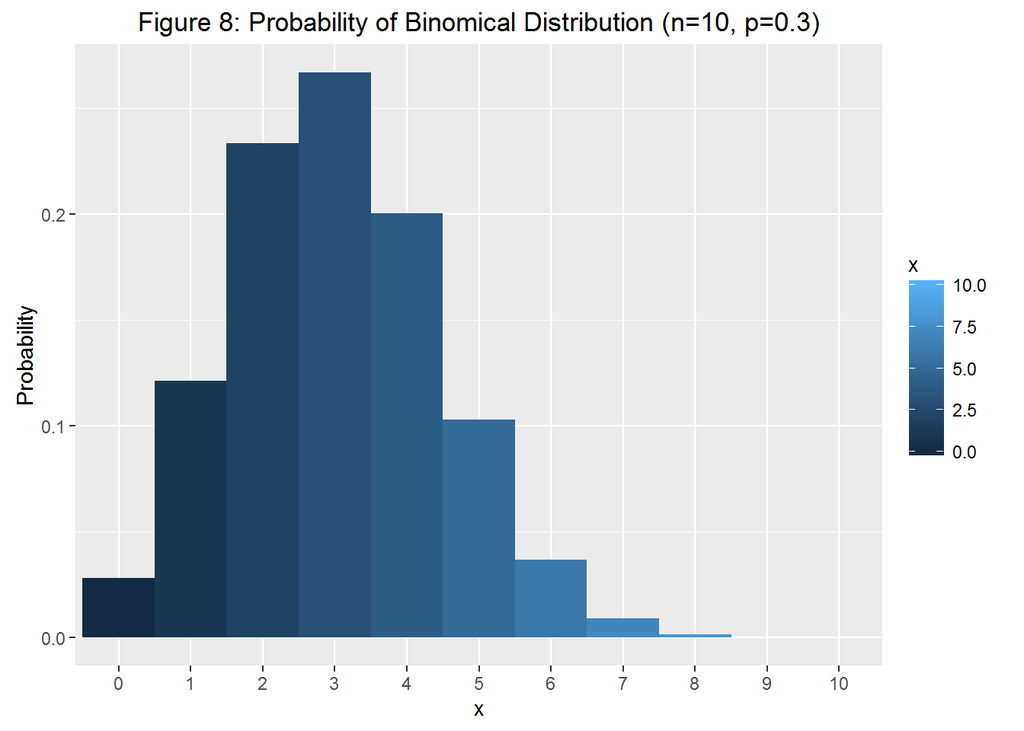

```r
g <- ggplot(sim_8, aes (x = as.factor(x), y = prob, fill = x ))+
     geom_bar(width = 1, stat = "identity")+
     labs(x="x", y=("Probability"),
     title = ("Figure 8: Probability of Binomical Distribution (n=10, p=0.3)"))
plot(g)
```